# Trabajo Práctico 1: Análisis Exploratorio de Datos- Machine Learning

## Integrantes: Cravero, Ulises y Pautasso, L. Nicolás.

## Tema: CS:GO Professional Matches.

### Introducción:

#### Counter-Strike Global Offensive es un juego lanzado en 2012. La longevidad del juego se debe principalmente a su enfoque competitivo y su escena profesional en constante crecimiento.

#### En marzo 2020 alcanzó su máximo histórico de jugadores simultáneos (1,1 millones de jugadores), lo que lo convirtió en el juego más jugado en la plataforma Steam, 8 años después de su lanzamiento.

### Dataset utilizado:

#### El dataset utilizado corresponde a las estadisticas finales de los partidos de jugadores profesionales en lo que respecta a competiciones oficiales desde noviembre 2015 hasta marzo 2020.

### Importamos el CSV y mostramos su tamaño y todas sus columnas

```python
pd.options.display.max_columns = None
players = pd.read_csv('players_mejor_3.csv')
```

```python
# Cantidad de registros y columnas del dataset original
players.shape
```

```
(198063, 101)
```

```python
# Muestra aleatoria
players.sample(3)
```

|  | date | player_name | team | opponent | country | player_id | match_id | event_id | event_name | best_of | map_1 | map_2 | map_3 | kills | assists | deaths | hs | flash_assists | kast | kddiff | adr | fkdiff | rating | m1_kills | m1_assists | m1_deaths | m1_hs | m1_flash_assists | m1_kast | … |
| --- | --- | --- | --- | --- | --- | --- | --- | --- | --- | --- | --- | --- | --- | --- | --- | --- | --- | --- | --- | --- | --- | --- | --- | --- | --- | --- | --- | --- | --- | --- |
| 64817 | 2018-11-15 | MadHacker | juicey | NASR | Israel | 9253 | 2329135 | 4153 | Asia Minor Middle East Closed Qualifier - IEM ... | 3 | Default | NaN | NaN | 23 | 4 | 37 | 5 | 0.0 | 66.0 | -14 | 53.1 | -1 | 0.70 | 23 | 4 | 37 | 5 | 0.0 | 66.0 | … |
| 84404 | 2018-06-26 | flickz | Chiefs | Grayhound | Australia | 11844 | 2324243 | 3836 | IEM Shanghai 2018 Oceania Closed Qualifier | 3 | Nuke | Overpass | NaN | 34 | 5 | 36 | 19 | NaN | 63.3 | -2 | 70.5 | -1 | 0.94 | 23 | 1 | 20 | 12 | 0.0 | 62.1 | … |
| 17264 | 2019-10-19 | malbsMd | Infinity | DETONA | Guatemala | 11617 | 2336741 | 4698 | ESL Pro League Season 10 Americas | 3 | Inferno | Train | NaN | 36 | 9 | 36 | 25 | 0.0 | 71.7 | 0 | 74.6 | 1 | 1.09 | 14 | 3 | 17 | 10 | 0.0 | 66.7 | … |

### Limpiamos las columnas que no necesitamos:

#### Estas corresponden mayoritariamente a columnas que:

- representan información obtenida en base a operaciones sobre otras columnas
- permitirían calcular directamente nuestra variable target
- son indentificadores y no aportan información ni medida de relación
- valores que no son útiles al momento de entrenar (las de mapa 2 y mapa 3 desagregadas)

```python
# Cantidad de registros y columnas del dataset modificado
players.shape
```

[output not shown]

```python
players = players.drop(columns=players.filter(regex='^m3_').columns)
```

```python
players.drop(columns=['date', 'player_id', 'match_id', 'event_id', 'kills', 'assists', 'deaths', 'hs', 'flash_assists', 'kast', 'adr', 'fkdiff', 'rating', 'kills_ct', 'deaths_ct', 'kddiff_ct', 'adr_ct', 'kast_ct', 'rating_ct', 'kills_t', 'deaths_t', 'kddiff_t', 'adr_t', 'kast_t', 'rating_t'],axis=1,inplace=True)
```

### Columnas del dataset:

#### VARIABLE DE SALIDA:

##### La variable a predecir es la variable 'kddiff', clasificándola en positiva o negativa al finalizar el primer mapa. El momento en que se realiza esto es al haber finalizado el primero de los mapas.

##### kddiff = diferencia entre muertes provocadas por el jugador y muertes propias al finalizar la partida. Es un número entero.

- valor minimo puede ser igual a las muertes propias (en negativo, si no mato ningun oponente)
- valor máximo puede ser igual a las muertes provocadas (si no fue nunca asesinado por un adversario)

### Balanceo de la variable de salida (kddiff)

```
Número de registros con KD Diff >= 0: 99170
Número de registros con KD Diff < 0: 98893
```

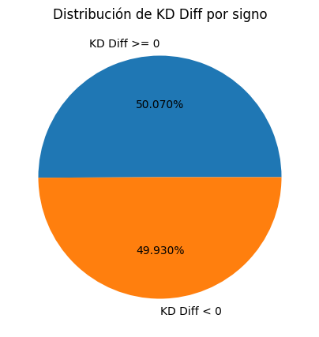

```python
# Obtenemos la cantidad de valores mayores y menores que 0
kddiff_pos = (players['kddiff'] >= 0).sum()
kddiff_neg = (players['kddiff'] < 0).sum()

print(f'Número de registros con KD Diff >= 0: {kddiff_pos}')
print(f'Número de registros con KD Diff < 0: {kddiff_neg}')

# Creamos un gráfico de torta de la distribución de los valores positivos y negativos de kddiff, mostrando los porcentajes con tres decimales (por el gran balanceo que existe)
plt.figure(figsize=(5, 5))
plt.pie([kddiff_pos, kddiff_neg], labels=['KD Diff >= 0', 'KD Diff < 0'], autopct='%1.3f%%')
plt.title('Distribución de KD Diff por signo')

plt.show()
```

- Como se puede ver en el gráfico anterior, la variable de salida kddiff tiene una cantidad similar de ejemplos en cada categoria (positivo o negativo), por lo cual se encuentra muy bien balanceada.
- Esto nos hace pensar que, sumado a la gran cantidad de registros del dataset, los modelos no estarán sesgados hacia ninguna de las dos clasificaciones, lo que significa que podría ser capaz de clasificar correctamente casos de ambas categorías por igual.

### Gráficos, comportamiento y afectación a la variable de salida de 5 variables de entrada y variable target:

#### VARIABLES DE ENTRADA:

##### Son las que podrían afectar a la de salida (por la naturaleza misma de ésta) son aquellas que están relacionadas con la capacidad de daño y supervivencia del jugador:

- m1_kills (se descarta)
- m1_assists
- m1_deaths (se descarta)
- m1_hs
- m1_fkdiff
- country

#### VARIABLE DE SALIDA:

- kddiff

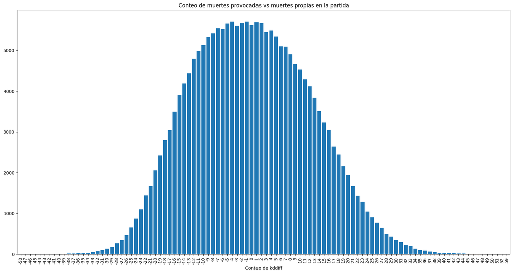

```python
# Gráficos de la variable target:
f, ax = plt.subplots(1, 1, figsize=(20, 10))

players.kddiff.value_counts().sort_index().plot.bar(ax=ax, width=0.8, xlabel='Conteo de kddiff', title='Conteo de muertes provocadas vs muertes propias en la partida')
```

### Analisis de valores extremos y/o nulos en las variables:

- La variable m1_kills: media de 18 muertes por partido. Presenta un registro que indica que un jugador eliminó 73 oponentes en un mismo mapa, lo cual ameritaría un chequeo de la información.
- La variable m1_deaths tiene un promedio de 18 y presenta también un valor extremo un tanto elevado, de 64 muertes en un mismo mapa, lo cual es imposible pues el máximo alcanzable es 42 (mapa regular y tiebreak).
- La variable m1_assists tiene un valor medio de 5 y presenta valor máximo de 22.
- En la variable m1_hs encontramos un valor promedio de 8 y un valor máximo de 38.
- En la variable de salida kddiff vemos el valor máximo en torno a 59, mientras que el valor mínimo es de -50, con una clara tendencia a una distribución normal.
- En lo que respecta a los valores obtenidos sobre la procedencia del jugador, hay una clara tendencia a ser originarios de paises con amplia trayectoria en esta clase de videojuegos, como son Estados Unidos, China, Brasil y Rusia.

### Hipótesis sobre los datos

#### Hipótesis 1:

##### El kddiff promedio de los jugadores pertenecientes a un equipo ubicado en el top 10 del ranking profesional en marzo de 2020 es mayor a 0. Esta hipótesis sugiere que los jugadores tendrán más probabilidades de tener un kddiff positivo al finalizar la partida cuando integran equipos mejor ubicados en el ranking profesional, ya que el desempeño del equipo como un todo les permitiría matar más oponentes y recibir menos muertes.

[figure not shown]

```python
from IPython.display import Image
Image(filename='rankingmarzo2020.png')
```

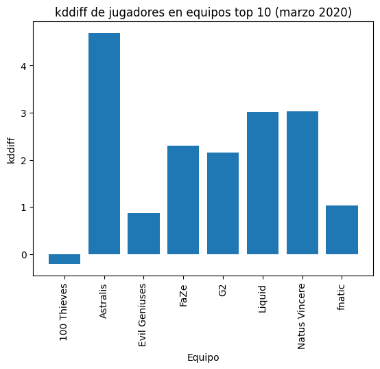

```python
# Obtenemos los registros de jugadores que estan en equipos top 10 de la imagen anterior
players_top10 = players[players['team'].isin(['Natus Vincere', 'Astralis', 'G2', 'Mouz', 'fnatic', 'Liquid', 'Evil Geniuses', '100 Thieves', 'Vitaly', 'FaZe'])]

# Sacamos el promedio por equipo utilizando groupby y sacando su media
kddiff_promedio_por_equipo = players_top10.groupby('team')['kddiff'].mean()

# Por cada promedio obtenido anteriormente, graficamos el valor y a cual pertenece
plt.bar(kddiff_promedio_por_equipo.index, kddiff_promedio_por_equipo.values)

plt.xlabel('Equipo')
plt.ylabel('kddiff')
plt.title('kddiff de jugadores en equipos top 10 (marzo 2020)')
plt.xticks(rotation=90, ha='center') # Para que los nombres salgan en vertical y se aprecie mejor el gráfico
plt.show()
```

- Según el gráfico obtenido en base a los valores calculados, podemos ver que, a excepción de un solo equipo, los promedios calculados se encuentran por encima de 0, lo cual confirma nuestra hipotesis.

### Hallazgo extra en los datos:

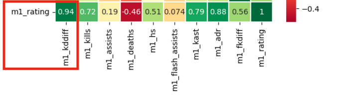

```python
from IPython.display import Image
Image(filename='correlacion_variables.png')
```

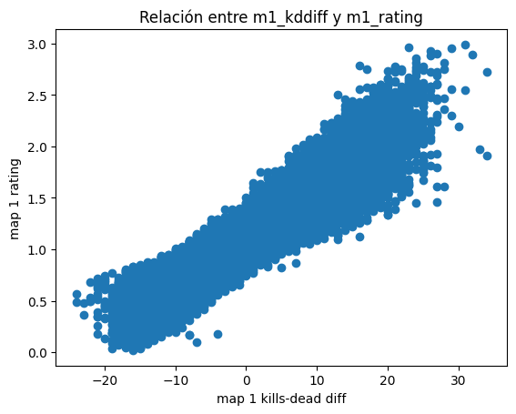

```python
# Seleccionamos las columnas a graficar
x = players['m1_kddiff']
y = players['m1_rating']

plt.xlabel('map 1 kills-dead diff')
plt.ylabel('map 1 rating')
plt.title('Relación entre m1_kddiff y m1_rating')

plt.scatter(x, y)

plt.show()
```

- A partir del mapa de calor obtenido en la correlación entre variables (m1_kddiff y m1_rating = 0.94), sumado al gráfico anterior (tendencia lineal), podemos ver que ambas variables se encuentran fuertemente relacionadas.
- Esto se condice con la definición formal de la variable rating, la cual tiene en cuenta una gran cantidad de medidas de performance del jugador a lo largo del mapa, teniendo como resultado que represente una buena medida de rendimiento general.
- Para conocer mas información acerca de esta variable y que estadísticas se tienen en cuenta a la hora de calcularla, se puede consultar el siguiente artículo de un conocido blog de estadisticas: https://www.hltv.org/news/20695/introducing-rating-20